# South Australia’s excellent renewable adventure

Author

Geoff Russell

Ah … quarto websites can’t quite match the power of Shiny … yet.

Please ignore … this is a work in progress … looking for the right tools to get a truly interactive document.

## Introduction

Germany is often regarded as the global renewable energy poster child, but the Australian state of South Australia (SA) gets more than double the electricity per person from wind and almost three times the electricity per person from solar power than Germany.

Many countries aspire to follow in Germany’s footsteps despite the fact that it has been astonishingly unsuccessful in replacing fossil fuels by wind and solar power during a solid and well funded 20 years of effort.

The following graph gives the per person low carbon electricity collected or generated for various countries; including nuclear, solar, wind, hydro and biomass. I’ve included biomass (burning forests as energy crops) despite there being considerable debate about it being low carbon without sequestration of the resulting carbon dioxide; and despite the health problems associated with wood smoke.

South Australia, and Australia as a whole has lessons for other countries on the growing problem of *“renewable energy backlogs”*. Why do so many countries have a backlog of wind and solar farms trying to connect to the grid? Is it just bureaucratic tape, or is there an intrinsic problem that makes connecting to the grid much harder than, for example, plugging another device into a computer network.

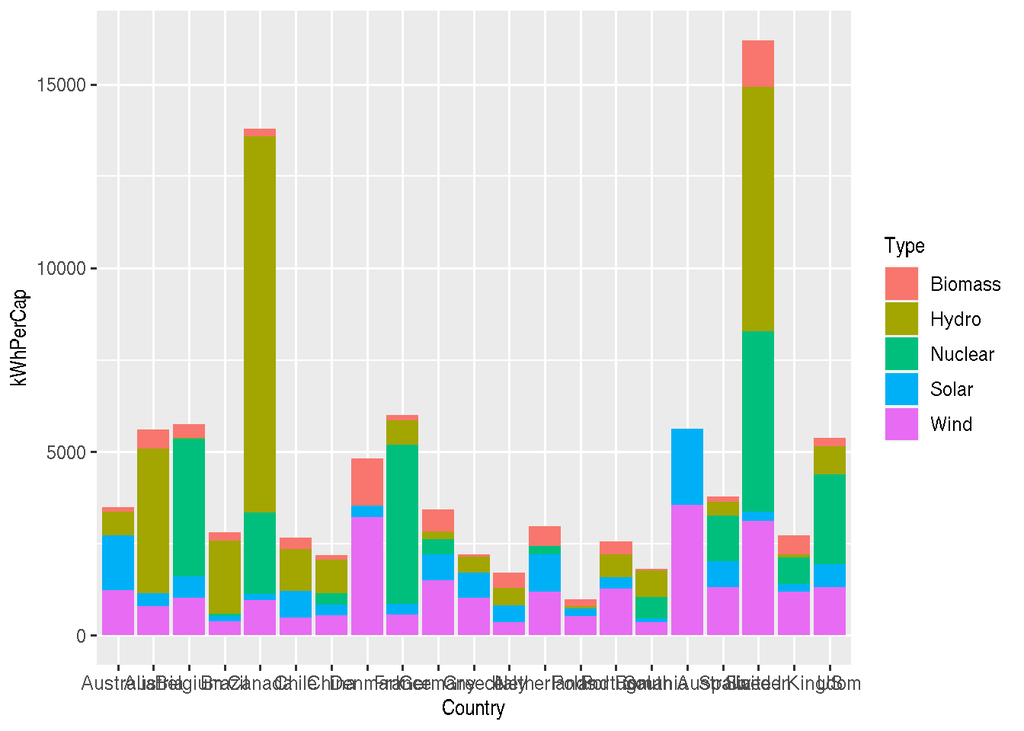

```r
library(tidyverse)
  dfpop<-read_csv("data/populationRenamed2022.csv")
  dfkwPerCapSolar<-read_csv("data/kwPerCap2022.csv") %>% arrange(desc(kwPerCap)) %>% slice_head(n=20)
  dfkwPerCapWind<-read_csv("data/kwPerCap2022Wind.csv") %>% arrange(desc(kwPerCap)) %>% slice_head(n=20)
  countries<-dfkwPerCapWind %>% select(Country)
  countries<-bind_rows(countries,tribble(~Country,"South Australia"))
  dfwsbh<-read_csv("data/wsbh.csv") %>% inner_join(countries)
  dfel<-bind_rows(tribble(~Country,~TWh,~Population,"South Australia",14.2,1.8e6),(read_csv("data/el.csv") %>% inner_join(countries)))
  dfwsbh<-dfwsbh %>% group_by(Country) %>% summarise(sum=sum(kWhPerCap)) %>% ungroup() %>% inner_join(dfwsbh)
  dfwsbh %>% ggplot()+geom_col(aes(x=Country,y=kWhPerCap,fill=Type))
```

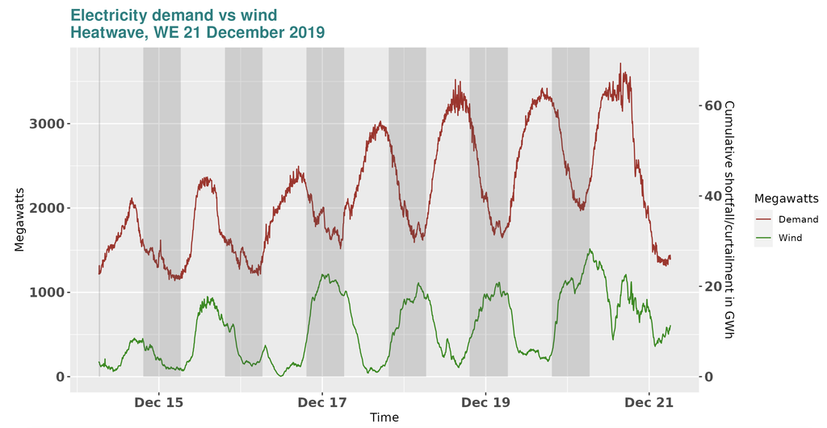

## Gridlock

**Really cool**

This is all about EMT modelling of grids.

## References

Hansen, James, Makiko Sato, Pushker Kharecha, David Beerling, Valerie Masson-Delmotte, Mark Pagani, Maureen Raymo, Dana Royer, and James Zachos. 2008. “Target Atmospheric $CO_2$: Where Should Humanity Aim?” *The Open Atmospheric Science Journal* 2: 271231.

Weinberg, Robert A. 2013. *The Biology of Cancer*. Garland Science, 2nd Edition.